# Pathway Enrichment

Jeremy Jacobson

January 29, 2026

### Purpose

This script runs pathway enrichment using leapR, using the drug viability data plus the long-format omics tables (RNA, global, and phospho).  
These long-format omics tables are batch corrected when necessary and have been returned from the Normalize Omics Notebook.

The main idea is:  
- Split samples into “sensitive” vs “resistant” for each drug (based on viability).  
- Run enrichment on each side.  
- Save the enrichment tables and plots so we can quickly scan which pathways show up for which drugs.

This file is written to be simple and repeatable. It loads the inputs from Synapse, runs the same workflow per modality, and stores results in a cache file so we do not re-run heavy work unless we need to.

**Note**: This will take a couple of hours to run the first time. **Do not overwrite the cache** unless completely necessary.

### Get Helper Scripts

These scripts contain the functions that we will call below.

- 00_cNF_helper_code.R is a basic helper script (Synapse helpers, metadata, and shared utilities).
- 03_leapr_biomarker.R contains the leapR wrapper functions, caching, and plotting helpers.

## Load in Data

These are the four main inputs we need - just like in analyze_modality. Drug viability plus the three long-format omics tables.

```r
# Drugs
drugs <- readr::read_tsv(synGet("syn69947322")$path)

# RNA
rlong <- readr::read_csv(synGet("syn71333780")$path)

# Global
glong <- readr::read_csv(synGet("syn70078416")$path)

# Phospho
plong <- readr::read_csv(synGet("syn70078415")$path)
```

## Run Pathway Enrichment for Each Omics Modality

Below, we run the same workflow three times, once per (omics) modality. The main things that change are:  
- which omics table we use - which column represents the feature - which geneset library we test (krbpaths vs kinasesubstrates)

Each call to `run_leapr_directional_one_cached()` does a few things:  
- Splits samples into “sensitive” vs “resistant” for each drug (based on viability).  
- Runs enrichment for each drug and direction.  
- Writes CSV outputs (if `write_csvs = TRUE`).  
- Saves an .Rdata cache so future runs are fast unless inputs or settings change.

One note about plots: `run_leapr_directional_one_cached()` computes the enrichment results, but it does not automatically save the pathway barplots.  
Those are generated by `save_leapr_plots()`. In this Rmd, I intentionally save plots for just **mirda** and **olaparib** so we do not generate hundreds of drug PDFs by accident.

**So, If you want more plots, just add more drugs to the `drugs = c(...)` list for each modality.**

### RNA (krbpaths).

For RNA, the features come from the `feature_id` column in the RNA long table (`rlong`). In most cases, this is a gene or transcript ID. Here we use the `krbpaths` gene set collection.

```r
res_bio_rna <- run_leapr_directional_one_cached(
  drugs        = drugs,
  df_long      = rlong,
  sample_col   = "Specimen",
  feature_col  = "feature_id",
  value_col    = "correctedAbundance",
  omic_label   = "rna",
  cache_path   = "../leapR_RNA_krbpaths_enrichment_direction_split.Rdata",
  write_csvs   = TRUE,
  always_rerun = FALSE,
  test_one     = FALSE,
  geneset_name = "krbpaths"
)

# This is where pathway plot PDFs get created.
# I keep the list short on purpose so the report stays readable.
save_leapr_plots(
  res_bio_rna,
  omic_label = "rna",
  drugs = c("Mirdametinib", "olaparib"),
  top_n = 15
)
```

Below are the RNA pathway plots created by `save_leapr_plots()`. These files get written to `figs/`.

```
## Converting page 1 to pathways_Mirdametinib_rna_resistant_top15_1.png... done!
## Converting page 1 to pathways_Mirdametinib_rna_sensitive_top15_1.png... done!
## Converting page 1 to pathways_olaparib_rna_resistant_top15_1.png... done!
## Converting page 1 to pathways_olaparib_rna_sensitive_top15_1.png... done!
```

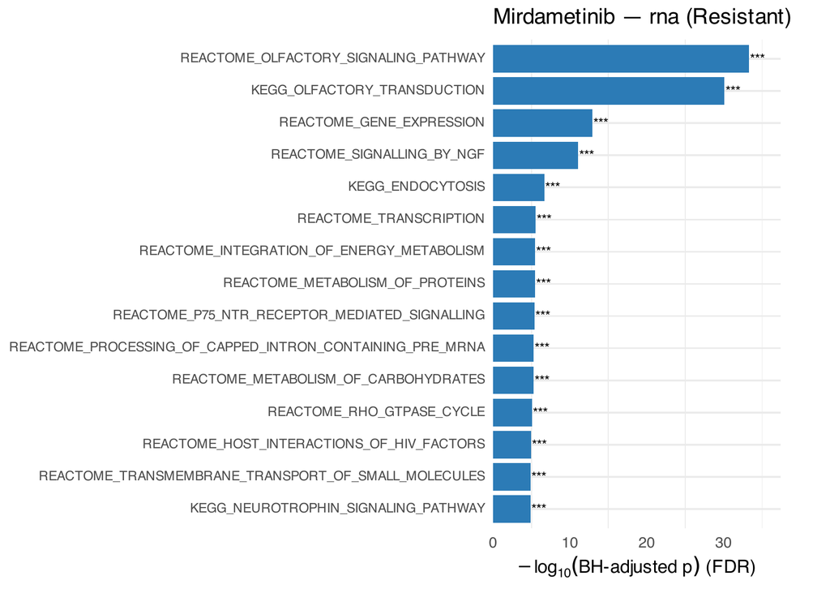

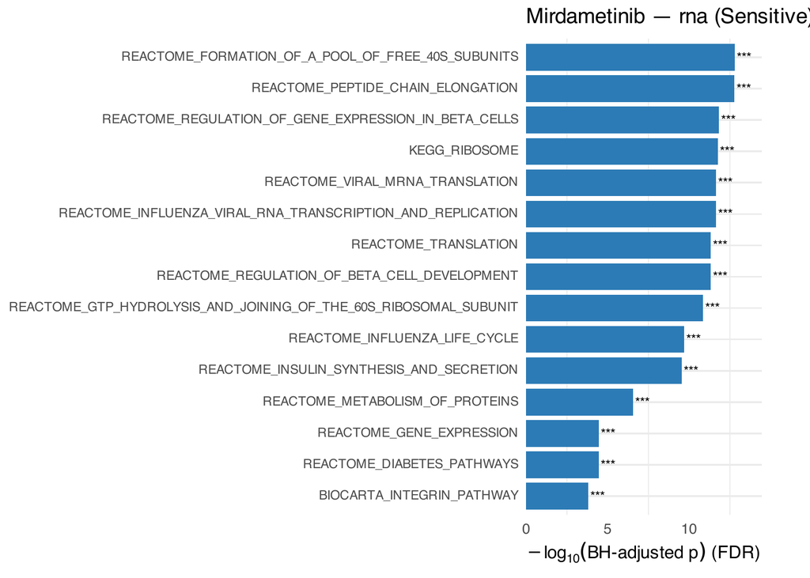

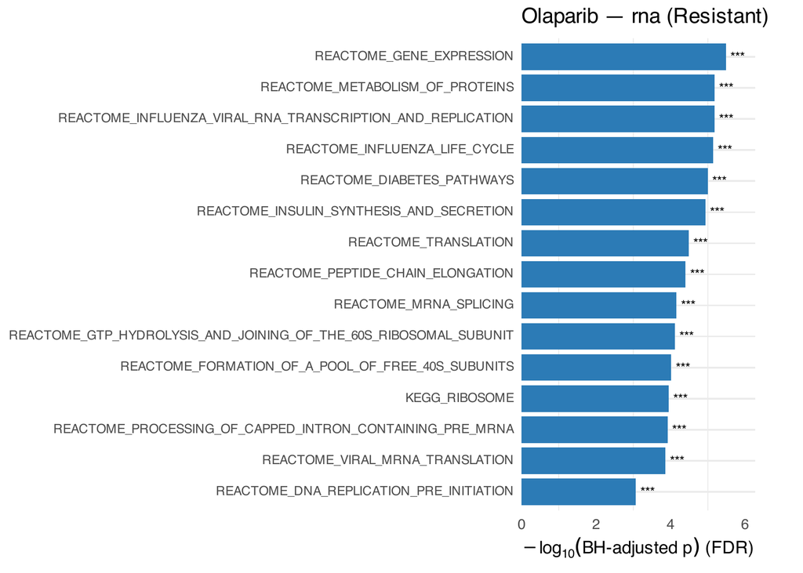

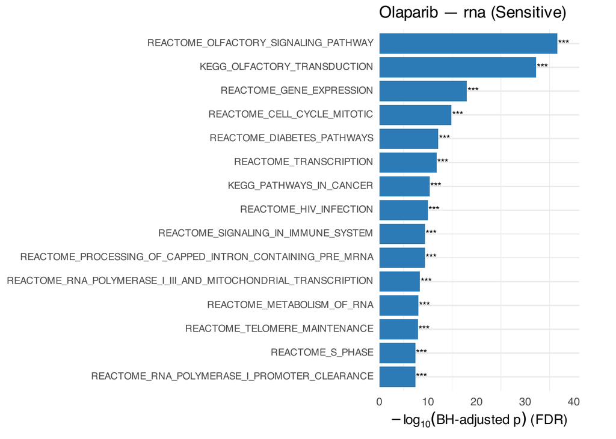

### Global Proteomics (krbpaths)

For global proteomics, the features are proteins in the `Gene` column. We keep the same `krbpaths` gene set collection so RNA and global are easier to compare.

```r
res_bio_global <- run_leapr_directional_one_cached(
  drugs        = drugs,
  df_long      = glong,
  sample_col   = "Specimen",
  feature_col  = "Gene",
  value_col    = "correctedAbundance",
  omic_label   = "global",
  cache_path   = "../leapR_Global_krbpaths_enrichment_direction_split.Rdata",
  write_csvs   = TRUE,
  always_rerun = FALSE,
  test_one     = FALSE,
  geneset_name = "krbpaths"
)

save_leapr_plots(
  res_bio_global,
  omic_label = "global",
  drugs = c("Mirdametinib", "olaparib"),
  top_n = 15
)
```

Here are the global pathway plots. Same idea as RNA, just using protein abundance instead of RNA abundance.

```
## Converting page 1 to pathways_Mirdametinib_global_resistant_top15_1.png... done!
## Converting page 1 to pathways_Mirdametinib_global_sensitive_top15_1.png... done!
## Converting page 1 to pathways_olaparib_global_resistant_top15_1.png... done!
## Converting page 1 to pathways_olaparib_global_sensitive_top15_1.png... done!
```

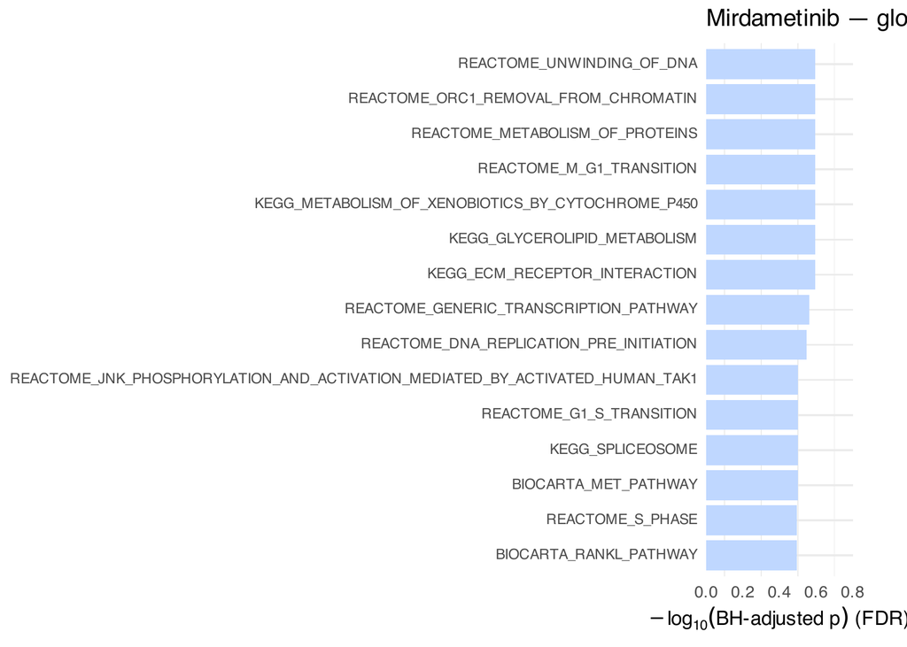

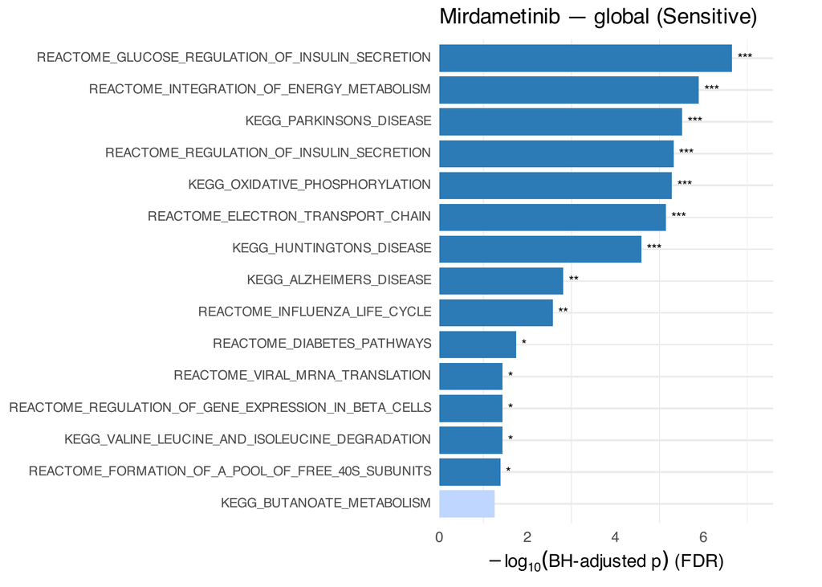

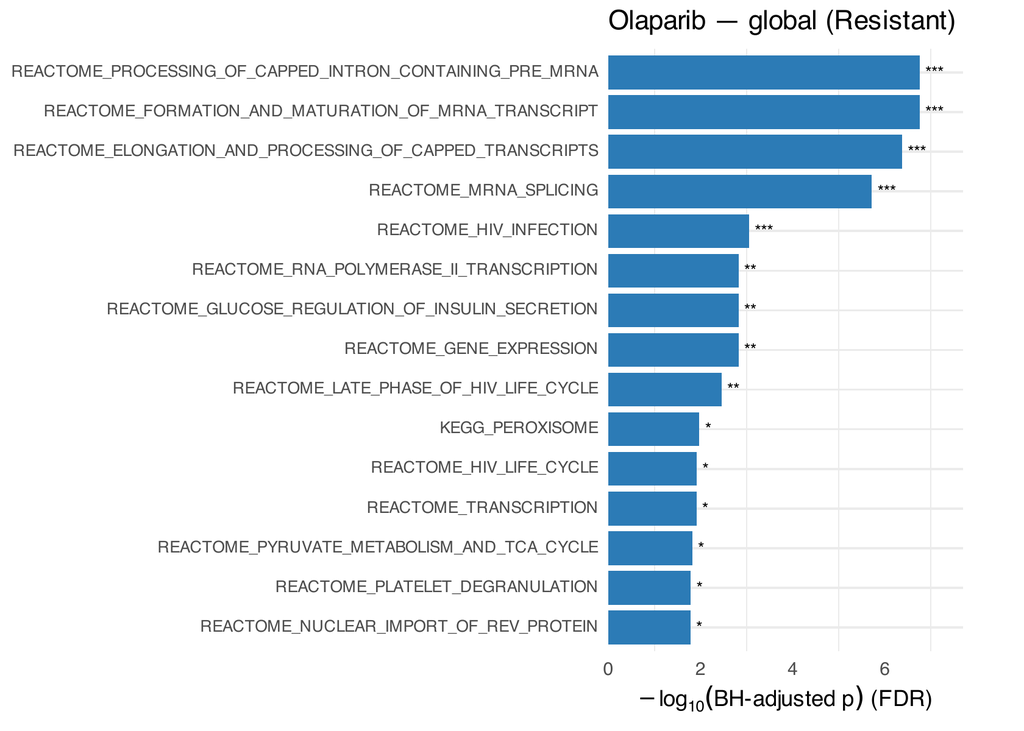

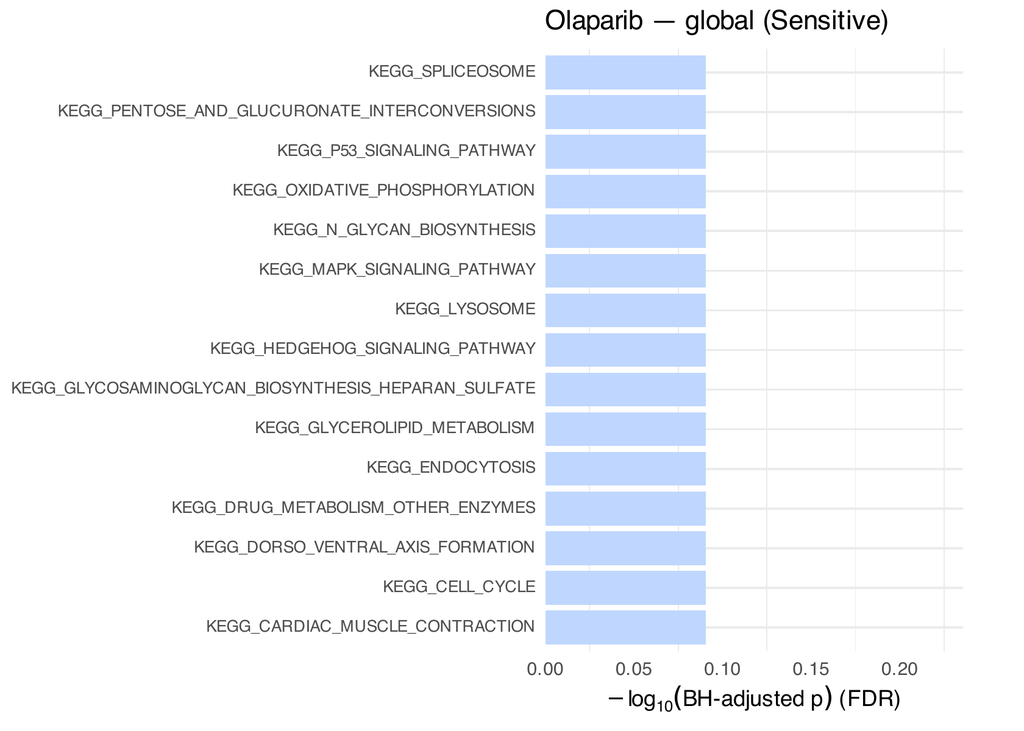

### Phospho Proteomics (kinasesubstrates)

For phospho, the features are phosphorylation sites in the `site` column. Here we use a phospho-specific gene set library, `kinasesubstrates`, because site-level maps more cleanly to kinase activity than to general pathway collections.

```r
res_bio_phospho <- run_leapr_directional_one_cached(
  drugs        = drugs,
  df_long      = plong,
  sample_col   = "Specimen",
  feature_col  = "site",
  value_col    = "correctedAbundance",
  omic_label   = "phospho",
  cache_path   = "../leapR_Phospho_kinasesubstrates_enrichment_direction_split.Rdata",
  write_csvs   = TRUE,
  always_rerun = FALSE,
  test_one     = FALSE,
  geneset_name = "kinasesubstrates"
)

save_leapr_plots(
  res_bio_phospho,
  omic_label = "phospho",
  drugs = c("Mirdametinib", "olaparib"),
  top_n = 15
)
```

Here are the phospho pathway plots. For mirdametinib and olaparib, no significant pathways are seen for the phospho data using drug viability.

```
## Converting page 1 to pathways_Mirdametinib_phospho_resistant_top15_1.png... done!
## Converting page 1 to pathways_Mirdametinib_phospho_sensitive_top15_1.png... done!
## Converting page 1 to pathways_olaparib_phospho_resistant_top15_1.png... done!
## Converting page 1 to pathways_olaparib_phospho_sensitive_top15_1.png... done!
```

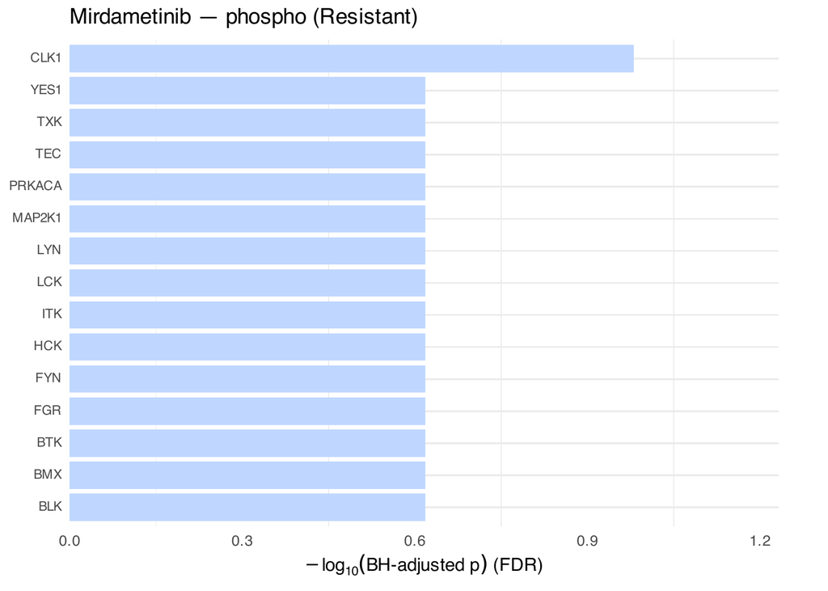

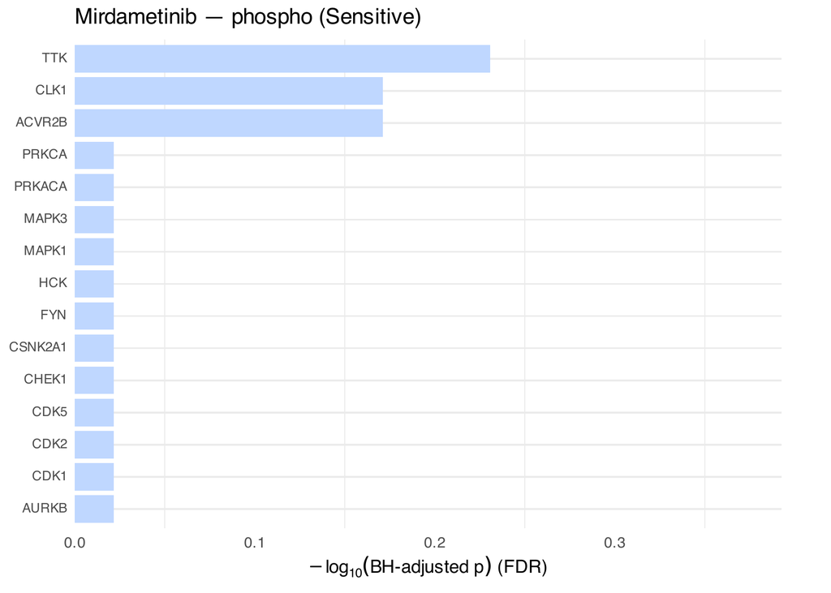

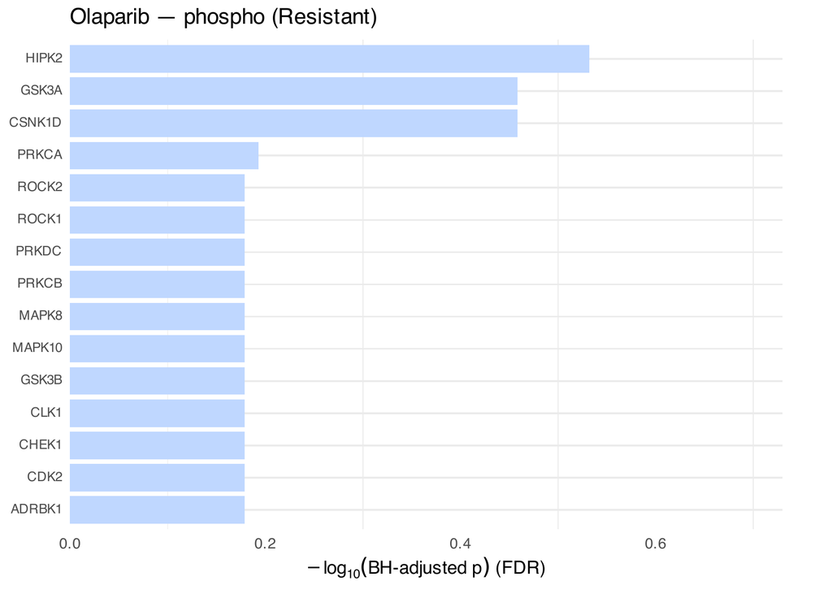

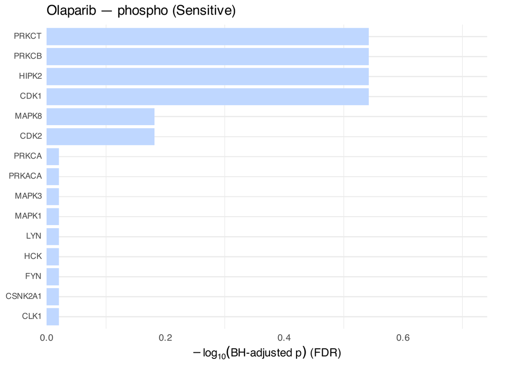

Overall we can see that the number of drugs with significant pathways vary significantly by omics type. RNA demonstrates 231, Global proteomics has 167, while phosphoproteomics only shows 44 with just 1-4 effected pathways per drug.

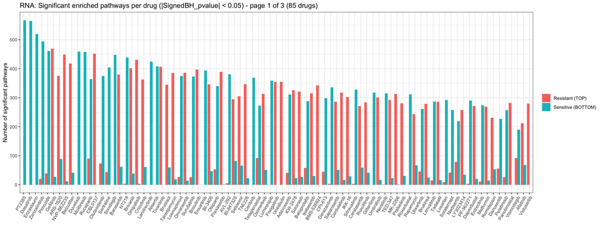

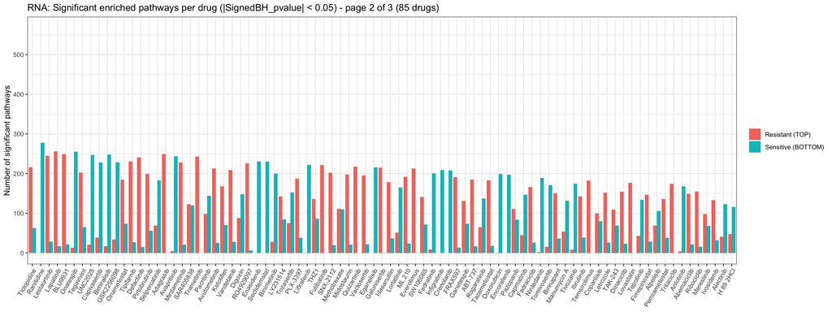

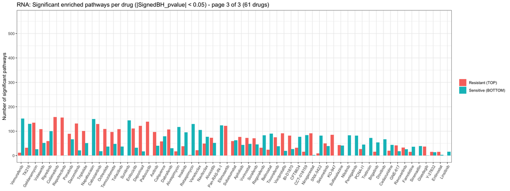

```r
alpha <- 0.05  #uses SignedBH_pvalue
page_size <- 85 #number of drugs per plot. If too many, the names will overlap.
plot_sig_pathways_one_omic_paged(res_bio_rna,    "rna",    alpha = alpha, page_size = page_size)
```

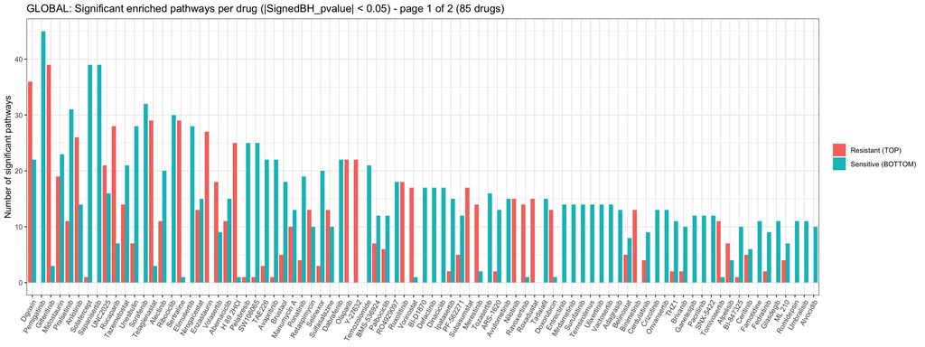

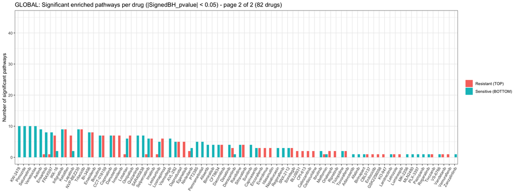

```r
plot_sig_pathways_one_omic_paged(res_bio_global, "global", alpha = alpha, page_size = page_size)
```

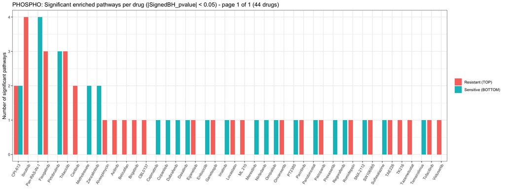

```r
plot_sig_pathways_one_omic_paged(res_bio_phospho,"phospho",alpha = alpha, page_size = page_size)
```

## Notes

- If you want to force a full rerun (ignore cache), set `always_rerun = TRUE`.
- If you only want to test quickly on one drug, set `test_one = TRUE` (useful for debugging).
- If you want plots for more drugs, add them to the `drugs = c(...)` list in each `save_leapr_plots()` call.
- All pathway plot files are saved under `figs/` with names like:
  - figs/pathways_{resistant|sensitive}_top.pdf.